# 경제자료분석과 예측 - #07 ARIMA 모형 (2)

2025년 2학기

## 행렬 기초 복습

## 다중회귀분석 모형

- 다중선형 회귀모형은 다음과 같이 표현할 수 있다:

\[ y_t = \beta_0 + \beta_1 x_{1,t} + \beta_2 x_{2,t} + \cdots + \beta_k x_{k,t} + \varepsilon_t \]

- 여기서 \(\varepsilon_t\)는 평균 0, 분산 \(\sigma^2\)를 가진다.
- 이 식은 단일 시점의 관계를 나타낸다.

## 행렬 표현으로의 전환

모든 관측값을 한꺼번에 표현하기 위해 다음과 같이 정의하자:

\[ \mathbf y = (y_1,\,\dots,y_T)'\quad \mathbf\varepsilon = (\varepsilon_1,\,\dots,\varepsilon_T)' \] \[ \boldsymbol\beta = (\beta_0,\beta_1,\dots,\beta_k)' \] \[ \mathbf X = \begin{bmatrix} 1 & x_{1,1} & x_{2,1} & \dots & x_{k,1} \\ 1 & x_{1,2} & x_{2,2} & \dots & x_{k,2} \\ \vdots & \vdots & \vdots & & \vdots \\ 1 & x_{1,T} & x_{2,T} & \dots & x_{k,T} \end{bmatrix} \]

그 결과 회귀식은 다음과 같이 표현된다:

\[ \mathbf y = \mathbf X\, \boldsymbol\beta + \mathbf\varepsilon \]

## 최소제곱 추정 (Least Squares Estimation)

최소제곱방법은 다음을 최소화하는 \(\boldsymbol\beta\)를 찾는다:

\[ \boldsymbol\varepsilon'\boldsymbol\varepsilon = (\mathbf y - \mathbf X\,\boldsymbol\beta)'(\mathbf y - \mathbf X\,\boldsymbol\beta) \]

그 결과 다음과 같은 해가 얻어진다:

\[ \hat{\boldsymbol\beta} = (\mathbf X'\mathbf X)^{-1}\mathbf X'\mathbf y \]

## 추정불가능성 및 랭크 조건

- 만약 \(\mathbf X\)가 **풀 컬럼 랭크(full column rank)** 가 아니라면,  
  \(\mathbf X'\mathbf X\)가 특이(singular)행렬이 되어 모형을 추정할 수 없다.
- 예컨대, 범주형 변수에서 더미변수를 **카테고리 수만큼** 생성하고 절편까지 포함했을 때 발생하는 “더미변수 함정(dummy-variable trap)”이 그 예다

## 적합값 및 교차검증(Cross Validation: CV)

- 적합값은 다음과 같이 표현된다:

\[ \hat{\mathbf y} = \mathbf X\,\hat{\boldsymbol\beta} = \mathbf X(\mathbf X' \mathbf X)^{-1}\mathbf X' \mathbf y = \mathbf H\,\mathbf y \]

여기서 \(\mathbf H = \mathbf X(\mathbf X'\mathbf X)^{-1}\mathbf X'\)를 **모자행렬(hat-matrix)** 라고 부른다.  
- 모자행렬의 대각성분을 \(h_1,\dots,h_T\)라 하면 교차검증(CV) 통계량은 다음과 같이 계산할 수 있다:

\[ \text{CV} = \frac1T \sum_{t=1}^T \left[ \frac{e_t}{1 - h_t} \right]^2 \]

여기서 \(e_t\)는 전체 자료 \(T\)로 적합한 모형의 잔차이다.  
→ 즉, \(T\)개의 별도 모형을 적합하지 않아도 CV를 구할 수 있다.

## 예측 및 예측구간

- 새로운 예측변수 값 \(\mathbf x^*\)에 대해 예측값은:

\[ \hat y = \mathbf x^*\hat{\boldsymbol\beta} = \mathbf x^*(\mathbf X' \mathbf X)^{-1}\mathbf X'\mathbf y \]

- 예측분산(추정)은 다음과 같이 주어진다:

\[ \hat\sigma_e^2 \left[1 + \mathbf x^*(\mathbf X' \mathbf X)^{-1}(\mathbf x^*)' \right] \]

- 95% 예측구간은 다음과 같이 계산할 수 있다:

\[ \hat y \pm 1.96\,\hat\sigma_e \sqrt{1 + \mathbf x^*(\mathbf X' \mathbf X)^{-1}(\mathbf x^*)'} \]

단, 예측변수의 미래값 \(\mathbf x^*\) 자체의 오차는 고려하지 않는다.  
따라서 그 오차가 크다면 이 예측구간은 과도하게 **좁게** 나올 수 있다.

## ARIMA 모형

## ARIMA 모형 소개

- **ARIMA 모형(Autoregressive Integrated Moving Average models)** 은 시계열 예측(time series forecasting)을 위한 또 다른 대표적 방법이다.
- **지수평활법(Exponential Smoothing)** 과 **ARIMA 모형**은  
  시계열 예측에서 가장 널리 사용되는 두 가지 접근법이다.
- 두 방법은 서로 **보완적인(complementary)** 관계에 있다.

## 두 접근법의 차이점

| 접근법 | 주요 개념 |
| --- | --- |
| **지수평활법** | 데이터 내의 **추세(trend)** 와 **계절성(seasonality)** 의 구조를 명시적으로 모델링 |
| **ARIMA 모형** | 데이터 내의 **자기상관(autocorrelation)** 구조를 설명하고자 함 |

즉,  
- 지수평활법은 시계열의 형태를 직접 기술하는 데 초점을 맞추고,  
- ARIMA 모형은 시계열 값들 간의 상관관계를 수학적으로 설명한다.

## ARIMA 모형 도입을 위한 준비

ARIMA 모형을 소개하기에 앞서, 두 가지 핵심 개념을 먼저 다루어야 한다.

1. **정상성(Stationarity)** — 시계열의 통계적 성질이 시간에 따라 변하지 않는 특성
2. **차분(Differencing)** — 비정상 시계열을 정상 시계열로 변환하는 기법

이 두 개념은 ARIMA 모형의 토대를 이루며, 다음 절에서 구체적으로 살펴볼 것이다.

## 정상성 (Stationarity)

## 정상 시계열이란?

**정상 시계열(stationary time series)** 이란 그 통계적 특성이 **관측 시점에 의존하지 않는 시계열**을 말한다.

즉,  
- **추세(trend)** 가 있거나  
- **계절성(seasonality)** 을 가진 시계열은 시간에 따라 평균이나 분산이 변하므로 **비정상(non-stationary)** 이다.

- 반면, **백색잡음(white noise)** 시계열은 언제 관측하더라도 통계적 특성이 동일하다.
- 따라서 백색잡음은 **정상 시계열**이다.

## 주기성과 정상성의 혼동

다음과 같은 경우는 다소 헷갈릴 수 있다.

- **주기적(cyclic)** 거동을 보이지만, 추세나 계절성이 없는 시계열은 **정상(stationary)** 이다.
- 이는 주기의 길이가 일정하지 않기 때문에, 실제 관측 전에 어디에서 최고점과 최저점이 나타날지 예측할 수 없기 때문이다.

즉, **주기(cycle)** 는 존재하더라도, 그 패턴이 일정하지 않다면 정상 시계열로 간주할 수 있다.

## 정상 시계열의 일반적 특징

일반적으로 정상 시계열은 장기적으로 **예측 가능한 패턴이 존재하지 않는다.**

- 시계열 그래프(time plot)는 대체로 **수평(horizontally flat)** 하며,
- 일정한 **분산(constant variance)** 을 보인다.
- 일부 주기적 변동이 있을 수 있으나, 추세나 계절적 구조는 없다.

## 예시: 어떤 시계열이 정상일까?

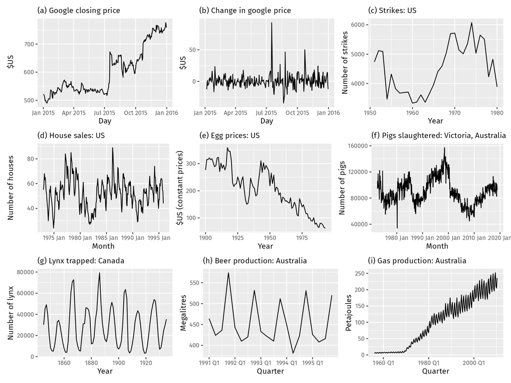

## 예시: 어떤 시계열이 정상일까?

그림의 아홉 개 시계열을 살펴보자. 이 중 어느 것이 정상일까?

- 뚜렷한 계절성이 있는 (d), (h), (i)는 **비정상**
- 추세나 수준(level)의 변화가 있는 (a), (c), (e), (f), (i)는 **비정상**
- 분산이 증가하는 (i) 역시 **비정상**

따라서 남는 것은 **(b)** 와 **(g)**, 두 개의 시계열이다. 이들이 **정상 시계열**이다.

## (g) 시계열의 주기성과 정상성

처음 보면 (g)의 강한 주기성(cyclic pattern)은 비정상처럼 보일 수 있다. 그러나 이 주기는 **비주기적(aperiodic)** 이다.

예를 들어,  
- 스라소니(lynx) 개체 수가 먹이 부족으로 감소하면 번식이 줄고,  
- 먹이원이 회복되면 다시 개체 수가 증가하는 식이다.  
- 하지만 이러한 사이클의 시점은 매번 달라 예측할 수 없다.

결국, 장기적으로 보면 주기의 시점이 불규칙하므로 (g) 시계열은 **정상(stationary)** 이다.

## 차분 (Differencing)

## 비정상 → 정상으로 만드는 방법

- **그림**의 (a) 패널에서 구글(Google) 주가는 **비정상(non-stationary)** 이었다.
- 그러나 (b) 패널에서 나타난 **일일 변화율(daily changes)** 은 **정상(stationary)** 하다.

즉,  
- 연속된 관측값의 차이를 계산하면 비정상 시계열을 정상 시계열로 변환할 수 있다.  
- 이 과정을 **차분(differencing)** 이라고 한다.

## 변환과 차분의 역할

- **로그 변환(logarithm)** : 분산(variance)을 안정화(stabilize)
- **차분(differencing)** : 시계열의 평균(mean)을 안정화하여 **수준 변화(level shift)** 나 **추세(trend)** 를 제거함

이를 통해 비정상성을 완화하거나 제거할 수 있다.

## ACF를 통한 정상성 진단

데이터의 시계열 그래프 외에도,  
**자기상관함수(ACF) 그래프**는 정상성 여부를 판별하는 데 유용하다.

- **정상 시계열**: ACF 값이 빠르게 0으로 수렴
- **비정상 시계열**: ACF 값이 천천히 감소
- 특히, 비정상 데이터에서는 \(r_1\) (1시차 자기상관)이 **크고 양(+)의 값**인 경우가 많다.

## ACF를 통한 정상성 진단 (구글 데이터)

```r
google_2018 <- gafa_stock |>
  filter(Symbol == "GOOG", year(Date) == 2018)
```

## ACF를 통한 정상성 진단 (구글 데이터)

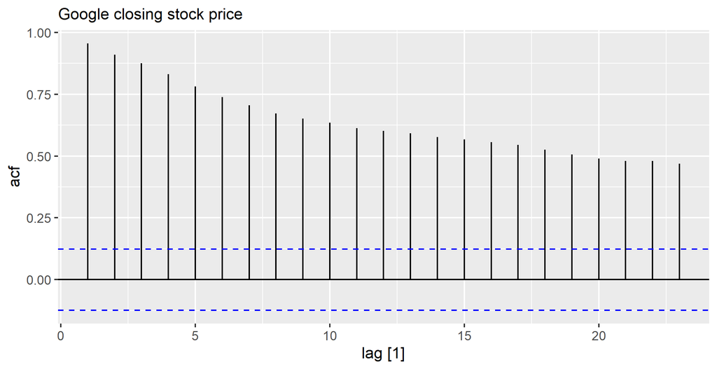

## ACF를 통한 정상성 진단 (구글 데이터)

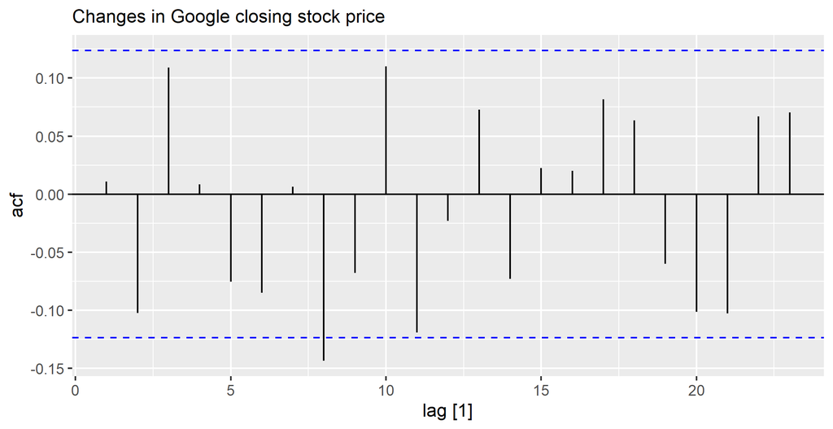

## 예시: 구글 주가의 차분 후 ACF

차분된 구글 주가 시계열의 ACF는 **백색잡음(white noise)** 과 매우 유사하다.

- 95% 신뢰구간을 벗어난 자기상관은 단 하나뿐이며,
- **Ljung-Box Q*** 통계량의 p-값은 **0.637 (h=10)** 이다.
- 시계열 모형의 잔차(residuals) 또는 데이터 자체가 “백색잡음(white noise)”인지 — 즉, 자기상관(autocorrelation) 이 존재하지 않는지를 검정하는 통계량

이는 구글 주가의 일일 변화가 이전 일들의 변화와 **상관이 없는(random and uncorrelated)** 무작위적 변동임을 시사한다.

## 랜덤워크 모형 (Random Walk Model)

## 차분(differencing)의 의미

차분된 시계열은 원래 시계열의 연속된 관측값 간의 차이를 의미하며, 다음과 같이 정의된다.

\[ y'_t = y_t - y_{t-1} \]

차분된 시계열은 첫 번째 관측값에 대한 차이를 계산할 수 없으므로 총 \(T - 1\)개의 값만 갖는다.

## 백색잡음이 되는 경우

만약 차분된 시계열이 **백색잡음(white noise)** 이라면, 원래 시계열의 모형은 다음과 같이 표현할 수 있다.

\[ y_t - y_{t-1} = \varepsilon_t, \]

이를 정리하면 **랜덤워크(random walk)** 모형이 된다.

\[ y_t = y_{t-1} + \varepsilon_t, \]

여기서 \(\varepsilon_t\)는 평균 0, 분산 \(\sigma^2\)의 백색잡음을 의미한다.

## 랜덤워크의 특징

랜덤워크 모형은 **비정상 시계열(non-stationary data)**, 특히 **금융 및 경제 데이터**에서 매우 널리 사용된다.

- 장기간 상승 또는 하락하는 **겉보기 추세(apparent trend)** 를 가짐
- 방향이 갑자기 바뀌는 **예측 불가능한 변동성(unpredictable changes)** 존재

이 모형에서의 예측치는 항상 마지막 관측값과 동일하다.

\[ \hat{y}_{T+h|T} = y_T \]

즉, 미래 변동이 상·하방으로 동일한 확률로 발생한다고 가정하기 때문에 이 모형은 **단순 나이브 예측(naïve forecast)** 의 기초가 된다.

## 랜덤워크 + 드리프트(Random Walk with Drift)

경우에 따라, 차분의 평균이 0이 아닌 경우가 있다. 이를 고려하면 다음과 같은 확장 모형이 된다.

\[ y_t - y_{t-1} = c + \varepsilon_t, \quad \text{또는} \quad y_t = c + y_{t-1} + \varepsilon_t \]

여기서 \(c\)는 연속된 관측값 사이의 **평균 변화량(mean change)** 이다.

- \(c > 0\): 시계열이 **상승 추세(drift upwards)** 를 가짐
- \(c < 0\): 시계열이 **하락 추세(drift downwards)** 를 가짐

이 모형은 **드리프트 방법(drift method)** 의 기초이며, DL는 앞에서 소개된 바 있다.

## 2차 차분 (Second-order Differencing)

## 2차 차분의 정의

가끔 1차 차분만으로는 시계열이 정상적으로 보이지 않을 수 있다.  
이때 **2차 차분(second-order differencing)** 을 적용할 수 있다.

\[ y''_t = y'_t - y'_{t-1} = (y_t - y_{t-1}) - (y_{t-1} - y_{t-2}) = y_t - 2y_{t-1} + y_{t-2} \]

이 경우 \(y''_t\)는 \(T - 2\)개의 값을 가지며, 이는 원래 시계열의 “변화의 변화(change in changes)”를 모델링하는 것이다.

## 2차 차분의 실무적 활용

- 실제 분석에서는 **2차 차분을 넘는 경우는 거의 없다.**
- 대부분의 비정상 시계열은 1차 또는 2차 차분만으로 정상성을 확보할 수 있다.

## 계절 차분 (Seasonal Differencing)

## 계절 차분의 개념

**계절 차분(seasonal differencing)** 은 같은 계절(또는 주기)에 해당하는 이전 관측값을 빼주는 과정이다.

\[ y'_t = y_t - y_{t-m} \]

여기서 \(m\)은 **계절의 주기(length of the season)** 이다.  
이 식은 “지연 차분(lag-m difference)”이라고도 부른다.

## 계절 차분 모형의 해석

계절 차분된 데이터가 백색잡음처럼 보인다면, 원래 시계열에 대한 적절한 모형은 다음과 같다.

\[ y_t = y_{t-m} + \varepsilon_t \]

이때 예측치는 이전 계절의 마지막 관측값과 동일하다.

즉, 이 모형은 **계절적 나이브 예측(seasonal naïve forecast)** 을 제공한다

## 예시: 호주 A10 약품 판매량

다음 그림은 호주에서 판매된 **A10 (항당뇨제, antidiabetic)** 의 월별 판매량 로그값(log-transformed data)을 계절 차분한 결과이다.

- 로그 변환과 계절 차분을 통해 시계열이 **상대적으로 정상적(stationary)** 으로 변했다.

## 예시: 호주 A10 약품 판매량

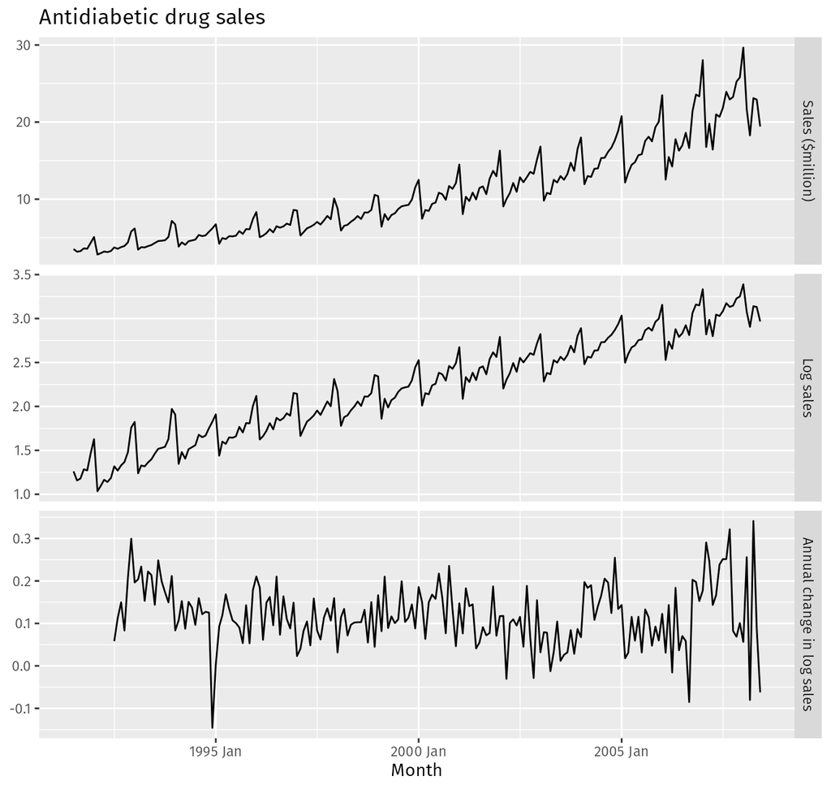

## 일반 차분과 계절 차분의 구분

계절 차분(seasonal differencing)과 구분하기 위해, 지연 1(lag 1)에서의 일반 차분(ordinary difference)을 **‘1차 차분(first difference)’** 라고 부르기도 한다.

\[ y'_t = y_t - y_{t-1} \]

## 계절 차분과 1차 차분을 모두 사용하는 경우

어떤 경우에는 **계절 차분**과 **1차 차분**을 모두 적용해야 데이터가 정상(stationary)으로 보일 수 있다.

다음 그림은 호주의 코르티코스테로이드(Corticosteroid) 약품 판매액을 보여준다.

- (상단 패널): 원자료 (판매액, $AUD 기준)
- (2번째 패널): 로그 변환(Log transformation)
- (3번째 패널): 계절 차분(Seasonal difference, lag=12)
- (하단 패널): 추가적인 1차 차분(First difference)

## 계절 차분과 1차 차분을 모두 사용하는 경우

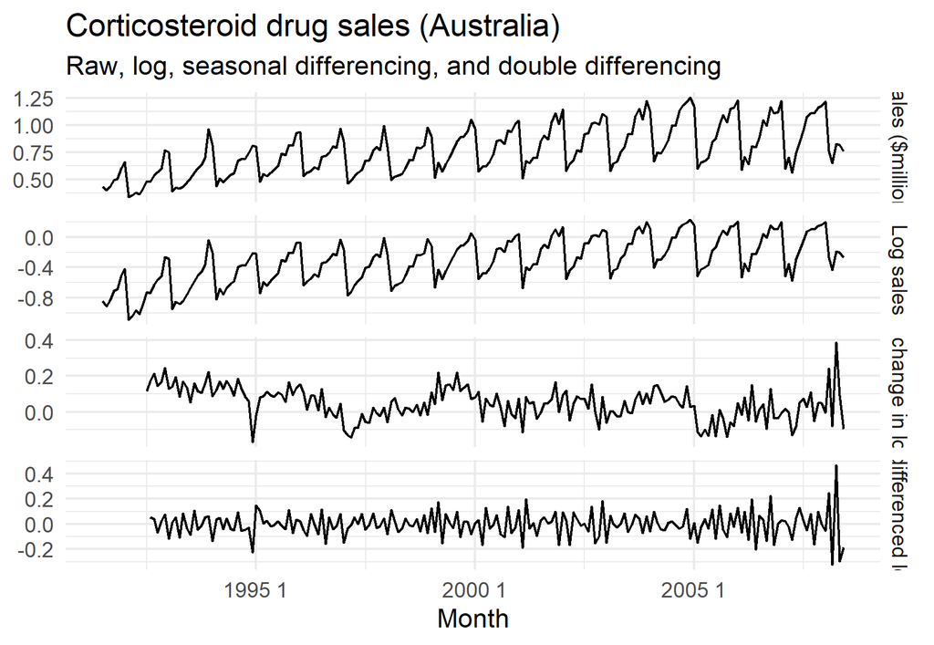

## 차분의 개수와 순서

차분의 개수와 순서는 **분석가의 판단**에 따라 달라질 수 있다.

- **A10 약품 판매량** 데이터와 **코르티코스테로이드 판매량** 데이터는 계절 차분 후에도 유사한 패턴을 보인다.
- 어떤 경우에는 **계절 차분까지만으로 충분**하고, 다른 경우에는 **1차 차분을 추가**해야 정상성을 얻을 수 있다.

> 결국, 차분의 정도(differencing order)는 **일부 주관적 판단(subjective judgment)** 이 개입될 수밖에 없다.

## 이중 차분의 일반식

### 수식 표현

\[ y'_t = y_t - y_{t-m} \quad \text{(계절 차분, Seasonal Difference)} \]

\[ y''_t = y'_t - y'_{t-1} \]

\[ \Rightarrow y''_t = (y_t - y_{t-m}) - (y_{t-1} - y_{t-m-1}) \\ = y_t - y_{t-1} - y_{t-m} + y_{t-m-1} \]

## 차분의 순서와 효과

### 순서에 따른 영향

- **계절 차분**과 **1차 차분**을 모두 적용할 경우  
  → **적용 순서는 결과에 영향을 주지 않는다.**
- 하지만 **계절성이 강한 데이터**의 경우, **계절 차분을 먼저 적용**하는 것이 일반적으로 권장된다.

> 이유:  
> - 계절 차분만으로도 정상성을 확보할 수 있는 경우가 많다.  
> - 반대로, 1차 차분을 먼저 하면 계절성이 남을 가능성이 높다.

## 과도한 차분에 대한 주의

차분을 **필요 이상으로 많이 적용**하면, 실제로 존재하지 않는 **가짜 자기상관(false autocorrelation)** 을 인위적으로 만들어낼 수 있다.

> ✅ 따라서,  
> **정상성을 얻기 위한 최소한의 차분만 수행**하는 것이 바람직하다.

## 차분의 해석 가능성

### 차분의 의미와 해석

차분을 사용할 때는 **그 의미가 해석 가능해야 한다.**

| 차분 유형 | 해석 |
| --- | --- |
| **1차 차분** | 바로 이전 시점 대비 변화량 |
| **계절 차분** | 1년 전(또는 동일 계절) 대비 변화량 |
| **기타 시차 차분** | 해석이 모호하므로 일반적으로 사용하지 않음 |

> “변화의 의미가 명확한” 차분만 사용하는 것이 좋다.

## 단위근 검정 (Unit Root Tests)

## 단위근 검정의 목적

시계열 데이터가 **정상(stationary)** 인지, 또는 **차분(differencing)** 이 필요한지를 보다 **객관적으로 판단**하기 위해 **단위근 검정(Unit root test)** 을 사용한다.

단위근 검정은 정상성에 대한 통계적 가설 검정으로, 데이터에 **단위근(unit root)** 이 존재하는지를 판별한다.

## 여러 가지 단위근 검정 중 KPSS 검정

단위근 검정에는 다양한 방법이 있으나, 본 교재에서는 **KPSS 검정(Kwiatkowski–Phillips–Schmidt–Shin test)** 을 사용한다  
(Kwiatkowski et al., 1992).

- **귀무가설 \(H_0\)** : 데이터가 **정상(stationary)** 하다.
- **대립가설 \(H_1\)** : 데이터가 **비정상(non-stationary)** 하다.

따라서,  
- **p값이 작을수록 (예: < 0.05)** → 정상성 기각 → **차분 필요**  
- **p값이 클수록 (예: > 0.05)** → 정상성 유지 → **차분 불필요**

## 여러 가지 단위근 검정 중 KPSS 검정

R에서는 `unitroot_kpss()` 함수로 계산한다.

```r
library(fpp3)

# KPSS 검정 (원시 데이터)
google_2018 |>
  features(Close, unitroot_kpss)
```

```
## # A tibble: 1 × 3
##   Symbol kpss_stat kpss_pvalue
##   <chr>      <dbl>       <dbl>
## 1 GOOG       0.573      0.0252
```

위의 결과에서 p값이 0.0252이므로, 귀무가설이 기각된다. → 데이터는 비정상(non-stationary) 이다. → 따라서 차분이 필요하다.

## 1차 차분 후 KPSS 검정

데이터를 1차 차분한 뒤, 다시 KPSS 검정을 수행한다.

```r
google_2018 |>
mutate(diff_close = difference(Close)) |>
features(diff_close, unitroot_kpss)
```

```
## # A tibble: 1 × 3
##   Symbol kpss_stat kpss_pvalue
##   <chr>      <dbl>       <dbl>
## 1 GOOG      0.0955         0.1
```

이번에는 p값이 0.1로 나타나며, → 데이터는 정상(stationary) 으로 판단된다.

## 자동 차분 결정: unitroot_ndiffs()

여러 번의 KPSS 검정을 수동으로 수행하지 않고, 필요한 1차 차분의 횟수를 자동으로 결정하는 함수:

```r
google_2018 |>
features(Close, unitroot_ndiffs)
```

```
## # A tibble: 1 × 2
##   Symbol ndiffs
##   <chr>   <int>
## 1 GOOG        1
```

→ 1차 차분이 필요함을 나타냄.

즉, ndiffs = 1 ⇒ 한 번의 차분으로 정상성을 확보할 수 있다.

## 계절 차분의 필요성 판단

계절성이 있는 시계열에서는 **계절 차분(seasonal differencing)** 이 필요한지를 판단해야 한다.

이를 위해 `unitroot_nsdiffs()` 함수를 사용한다.

## 계절 강도(Seasonal Strength)

이 함수는 **계절 강도(seasonal strength, \(F_S\))** 값을 이용하여 필요한 계절 차분 횟수를 결정한다.

\[ F_S < 0.64 \quad \Rightarrow \quad \text{계절 차분 불필요} \] \[ F_S \ge 0.64 \quad \Rightarrow \quad \text{1회의 계절 차분 필요} \]

> ✅ 정리  
> - \(F_S\)는 데이터 내 계절성이 얼마나 강한지를 측정하는 지표  
> - 계절성이 약하면(0.64 미만) 차분 불필요  
> - 계절성이 강하면(0.64 이상) **1회 계절 차분 필요**

## 예시: 호주 전체 소매판매

```r
aus_total_retail <- aus_retail |>
summarise(Turnover = sum(Turnover))

# 로그 변환 후 계절 차분 판단

aus_total_retail |>
mutate(log_turnover = log(Turnover)) |>
features(log_turnover, unitroot_nsdiffs)
```

```
## # A tibble: 1 × 1
##   nsdiffs
##     <int>
## 1       1
```

→ 계절 차분 1회 필요 (nsdiffs = 1)

## 계절 차분 후, 추가로 1차 차분 판단

```r
aus_total_retail |>
mutate(log_turnover = difference(log(Turnover), 12)) |>
features(log_turnover, unitroot_ndiffs)
```

```
## # A tibble: 1 × 1
##   ndiffs
##    <int>
## 1      1
```

→ 계절 차분 1회 + 1차 차분 1회가 필요함을 의미한다.

## 단위근 검정 요약 (Summary of Unit Root Tests)

### 주요 함수와 해석

| 함수 | 목적 | 출력값 | 의미 |
| --- | --- | --- | --- |
| `unitroot_kpss()` | KPSS 검정 (정상성 여부 판별) | p값 | p < 0.05 → **비정상** |
| `unitroot_ndiffs()` | 필요한 1차 차분 수 계산 | 정수 | `ndiffs = 0` 또는 `1` |
| `unitroot_nsdiffs()` | 필요한 계절 차분 수 계산 | 정수 | `nsdiffs = 0` 또는 `1` |

## 결론

- **KPSS 및 단위근 검정(Unit Root Tests)** 을 활용하면 시계열이 **몇 번의 차분을 통해 정상성을 확보할 수 있는지** 객관적으로 판단할 수 있다.

> 즉, 검정 결과는 데이터의 **비정상성(Non-stationarity)** 을 **차분 횟수(differencing order)** 형태로 정량화해 준다.

## 후방이동 연산자 (Backward Shift Operator)

## 개념 소개

**후방이동 연산자(backward shift operator)** \(B\) 는  
시계열의 **지연(lag)** 을 간편하게 표현하기 위한 표기법이다.

\[ B y_t = y_{t-1} \]

(일부 참고문헌에서는 “lag”의 의미로 \(L\)을 사용하기도 한다.)

즉, \(B\)가 \(y_t\)에 작용하면 데이터를 한 시점 뒤로 이동시키는 효과를 가진다.

## 후방이동 연산자의 확장

두 번 적용하면 2시점 전 값을 얻는다.

\[ B(B y_t) = B^2 y_t = y_{t-2} \]

월별 데이터(monthly data)의 경우, “전년도 같은 달(the same month last year)”을 나타낼 때는:

\[ B^{12} y_t = y_{t-12} \]

## 차분(differencing)의 수식 표현

후방이동 연산자는 **차분 연산(differencing)** 을 간결히 표현하는 데 유용하다.

1차 차분은 다음과 같다.

\[ y'_t = y_t - y_{t-1} = y_t - B y_t = (1 - B)y_t \]

따라서 1차 차분은 연산자 \((1 - B)\)로 표현할 수 있다.

## 2차 차분

2차 차분은 다음과 같이 나타낼 수 있다.

\[ \begin{aligned} y''_t &= y_t - 2y_{t-1} + y_{t-2} \\ &= (1 - 2B + B^2)y_t \\ &= (1 - B)^2 y_t \end{aligned} \]

## 일반화된 d차 차분

일반적으로, **d차 차분(d-th order difference)**은다음과 같이 표현할 수 있다.

\[ (1 - B)^d y_t \]

즉, 차분의 차수가 증가할수록 \((1 - B)\)를 반복적으로 적용하는 형태로 일반화된다.

## 연산자의 대수적 성질

후방이동 연산자는 **일반적인 대수 규칙(algebraic rules)** 을 따르므로 곱셈, 결합, 전개 등의 연산이 가능하다.

특히, **계절 차분(seasonal differencing)** 과 **1차 차분(first differencing)** 을 결합할 때 유용하다.

## 예시: 계절 + 1차 차분의 결합

\[ (1 - B)(1 - B^m)y_t \]

이를 전개하면:

\[ (1 - B - B^m + B^{m+1})y_t = y_t - y_{t-1} - y_{t-m} + y_{t-m-1} \]

이 결과는 앞서 유도한 **이중 차분(seasonal + first difference)** 과 동일하다.

> ✅ 정리  
> - \(B\): 데이터를 한 시점 뒤로 이동시키는 연산자  
> - \((1 - B)\): 1차 차분  
> - \((1 - B)^d\): d차 차분  
> - \((1 - B)(1 - B^m)\): 1차 + 계절 차분 결합

## 자기회귀모형 (Autoregressive Models)

## 자기회귀모형의 개념

**다중회귀모형(multiple regression model)** 은 예측변수(predictors)의 선형결합(linear combination)을 이용해 관심 변수(예측 대상)를 예측했다.

**자기회귀모형(autoregressive model, AR model)** 은 이와 달리 **과거 시점의 자기 자신의 값(past values)** 을 이용해 현재 값을 예측한다.

> 즉, “자기회귀(autoregression)”란 변수를 자기 자신에 대해 회귀(regression)시키는 것이다.

## 일반적인 AR(p) 모형의 형태

자기회귀모형의 차수(order)가 \(p\)일 때, AR(\(p\)) 모형은 다음과 같이 표현된다.

\[ y_t = c + \phi_1 y_{t-1} + \phi_2 y_{t-2} + \cdots + \phi_p y_{t-p} + \varepsilon_t \]

여기서  
- \(\varepsilon_t\): 평균 0, 분산 \(\sigma^2\)의 백색잡음(white noise)  
- \(p\): 회귀에 포함된 시차(lags)의 개수

이 모형은 다중회귀식과 유사하지만, 예측변수가 외생변수 대신 **지연된 \(y_t\) 값들(lagged values)** 로 구성되어 있다.

## 자기회귀모형의 유연성

- AR 모형은 다양한 시계열 패턴을 유연하게 표현할 수 있다.
- 모수(parameter) \(\phi_1, \ldots, \phi_p\) 값의 변화에 따라 시계열의 모양이 크게 달라진다.
- 오차항 \(\varepsilon_t\)의 분산은 시계열의 **규모(scale)** 만 바꾸고 **패턴(pattern)** 자체에는 영향을 주지 않는다.

## 예시: AR(1)과 AR(2) 모형

두 가지 서로 다른 자기회귀모형의 예시를 살펴보자.

두 경우 모두  
\(\varepsilon_t \sim \text{WN}(0,1)\) (정규분포를 따르는 백색잡음)

## 서로 다른 파라미터를 가진 모형의 예시

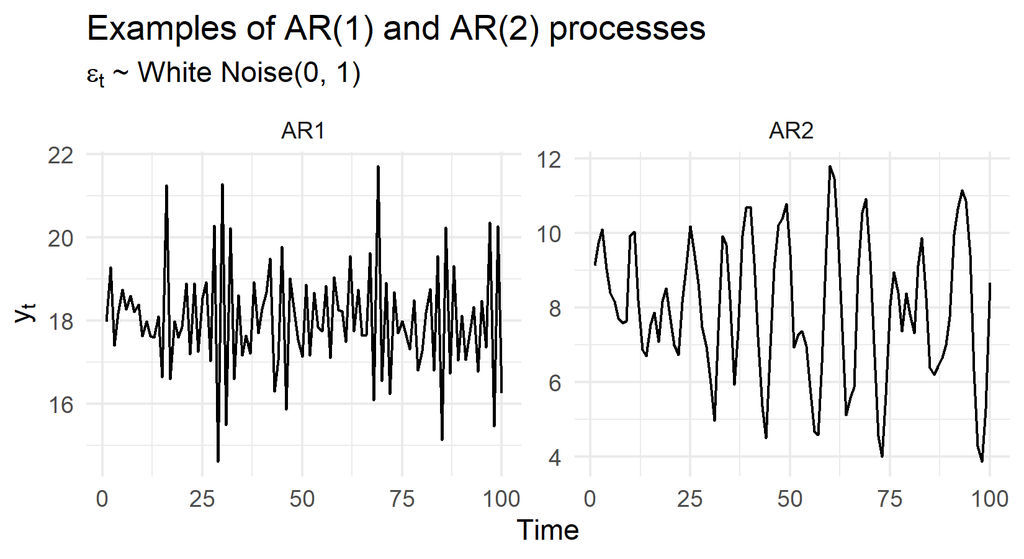

## AR(1) 모형의 다양한 특성

AR(1) 모형은 다음과 같이 표현된다.

\[ y_t = c + \phi_1 y_{t-1} + \varepsilon_t \]

모수(parameter) \(\phi_1\)과 \(c\) 값에 따라 다양한 형태의 시계열 패턴이 나타난다.

| 조건 | 결과적 형태 |
| --- | --- |
| \(\phi_1 = 0, \; c = 0\) | \(y_t\)는 **백색잡음(white noise)** |
| \(\phi_1 = 1, \; c = 0\) | \(y_t\)는 **랜덤워크(random walk)** |
| \(\phi_1 = 1, \; c \neq 0\) | \(y_t\)는 **드리프트를 포함한 랜덤워크(random walk with drift)** |
| \(\phi_1 < 0\) | \(y_t\)는 **평균 주위에서 진동(oscillation)** 함 |

## 정상성 조건의 필요성

자기회귀모형은 일반적으로 **정상 시계열(stationary series)** 에만 적용된다.  
따라서 모수(parameter)의 값은 다음 조건을 만족해야 한다.

### AR(1) 모형의 조건

\[ -1 < \phi_1 < 1 \]

### AR(2) 모형의 조건

\[ -1 < \phi_2 < 1, \quad \phi_1 + \phi_2 < 1, \quad \phi_2 - \phi_1 < 1 \]

### AR(p) 모형 (\(p \ge 3\))

- 제약조건이 훨씬 복잡하지만, `fable` 패키지는 모형 추정 시 이러한 제약을 자동으로 적용한다.

## 이동평균모형 (Moving Average Models)

## 이동평균모형의 개념

**이동평균모형(Moving Average model, MA model)** 은 과거의 예측변수 값이 아닌, **과거의 오차항(forecast errors)** 을 이용하여 시계열을 설명한다.

\[ y_t = c + \varepsilon_t + \theta_1 \varepsilon_{t-1} + \theta_2 \varepsilon_{t-2} + \cdots + \theta_q \varepsilon_{t-q} \]

여기서  
- \(\varepsilon_t\): 평균 0, 분산 \(\sigma^2\) 의 백색잡음(white noise)  
- \(q\): 모형의 차수(order)

이 모형을 **MA(\(q\)) 모형**이라 부른다.

## MA 모형의 의미

각 시점의 \(y_t\)는 과거 오차항들의 **가중 이동평균(weighted moving average)** 으로 볼 수 있다.

하지만 일반적인 이동평균(smoothing)과는 다르다.

| 구분 | 목적 |
| --- | --- |
| **이동평균모형 (MA model)** | 미래 값을 예측 (forecasting) |
| **이동평균 평활(MA smoothing)** | 과거 추세(trend-cycle)를 추정 |

## 예시: MA(1)과 MA(2) 모형

- 왼쪽: MA(1)  
  \[ y_t = 20 + \varepsilon_t + 0.8\varepsilon_{t-1} \]
- 오른쪽: MA(2)  
  \[ y_t = \varepsilon_t - \varepsilon_{t-1} + 0.8\varepsilon_{t-2} \]

\(\varepsilon_t \sim N(0,1)\), 즉 평균 0, 분산 1의 정규 백색잡음이다.

## 예시: MA(1)과 MA(2) 모형

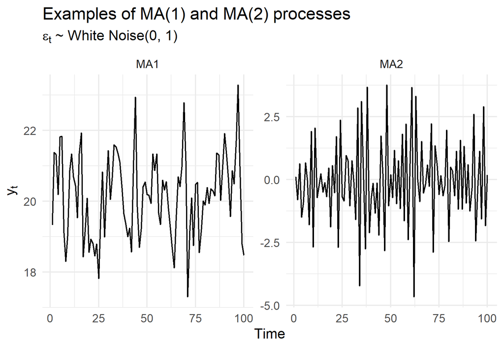

## 모수 변화에 따른 패턴 (Effect of Parameter Changes)

### MA 모형의 파라미터 변화

- \(\theta_1, \ldots, \theta_q\) 값을 바꾸면 다양한 시계열 패턴(time series patterns)을 얻을 수 있다.
- 오차항의 분산(variance of \(\varepsilon_t\))은 시계열의 **규모(scale)** 만 바꾸며, **패턴(pattern)** 에는 영향을 주지 않는다.

## AR 모형과 MA 모형의 관계

### AR 모형을 MA(∞)로 표현

모든 **정상 AR(\(p\)) 모형**은 **MA(∞) 모형**으로 표현가능하다.

예를 들어, AR(1) 모형을 반복 대입(substitution)하면:

\[ \begin{aligned} y_t &= \phi_1 y_{t-1} + \varepsilon_t \\ &= \phi_1 (\phi_1 y_{t-2} + \varepsilon_{t-1}) + \varepsilon_t \\ &= \phi_1^2 y_{t-2} + \phi_1 \varepsilon_{t-1} + \varepsilon_t \\ &= \phi_1^3 y_{t-3} + \phi_1^2 \varepsilon_{t-2} + \phi_1 \varepsilon_{t-1} + \varepsilon_t \end{aligned} \]

## AR(1)의 MA(∞) 표현

### AR(1) → MA(∞)

\[ y_t = \varepsilon_t + \phi_1 \varepsilon_{t-1} + \phi_1^2 \varepsilon_{t-2} + \phi_1^3 \varepsilon_{t-3} + \cdots \]

단,  
\(-1 < \phi_1 < 1\) 이면 \(\phi_1^k\) 값은 \(k\)가 커질수록 0에 수렴한다.

> 따라서 AR(1) 모형은 MA(∞) 형태로 표현 가능하다.

## MA 모형의 가역성

### MA → AR(∞)

반대로, 적절한 제약조건을 부여하면 MA(\(q\)) 모형은 AR(∞) 형태로 표현할 수 있다.

이때 모형을 **가역(invertible)** 하다고 한다.

예를 들어, MA(1) 모형은 다음과 같다.

\[ y_t = \varepsilon_t + \theta_1 \varepsilon_{t-1} \]

이를 AR(∞) 형태로 변환하면:

\[ \varepsilon_t = \sum_{j=0}^{\infty} (-\theta_1)^j y_{t-j} \]

## 가역성 조건 (Invertibility Constraints)

### 조건 해석

- \(|\theta_1| > 1\):  
  지연(lag)이 커질수록 가중치 증가 → **비현실적**
- \(|\theta_1| = 1\):  
  모든 시차(lag)의 영향이 동일 → **비현실적**
- \(|\theta_1| < 1\):  
  최근 관측값이 과거보다 더 큰 영향 → **가역(invertible)**

> 따라서 MA 모형이 현실적으로 타당하려면 \(|\theta_1| < 1\) 이어야 한다.

## MA 모형의 제약조건 요약

| 모형 | 제약조건 |
| --- | --- |
| **MA(1)** | \(-1 < \theta_1 < 1\) |
| **MA(2)** | \(-1 < \theta_2 < 1,\ \theta_2 + \theta_1 > -1,\ \theta_1 - \theta_2 < 1\) |
| **MA(q ≥ 3)** | 제약조건이 더 복잡하지만 `fable` 패키지가 자동 처리 |

### ✅ 정리

- **MA 모형**은 과거의 오차항(\(\varepsilon\))을 이용해 시계열을 예측한다.
- **정상 AR 모형**은 MA(∞) 형태로 표현 가능하다.
- **가역성 조건 (\(|\theta_i| < 1\))** 을 만족해야 정상적이고 현실적인 모형으로 간주된다.

## 비계절 ARIMA 모형 (Non-seasonal ARIMA Models)

## 비계절 ARIMA

- ARIMA 모형의 정의 차분(differencing)을 자기회귀(AR)와 이동평균(MA) 모형에 결합하면 비계절 ARIMA 모형 (Non-seasonal ARIMA model) 을 얻는다.
- ARIMA: AutoRegressive Integrated Moving Average 여기서 Integrated는 “차분의 역(reverse)”을 의미한다.

## ARIMA모형의 일반식

\[ y'_t = c + \phi_1 y'_{t-1} + \cdots + \phi_p y'_{t-p} + \theta_1 \varepsilon_{t-1} + \cdots + \theta_q \varepsilon_{t-q} + \varepsilon_t \]

여기서  
- \(y'_t\): 차분된 시계열(한 번 이상 차분일 수 있음)  
- \(\varepsilon_t\): 백색잡음(white noise)  
- \(p,d,q\): 각각 AR 차수, 차분 차수, MA 차수

이 모형을 **ARIMA(\(p,d,q\))** 라고 한다.

## ARIMA 모형의 구성 요소

| 구성 요소 | 의미 |
| --- | --- |
| \(p\) | 자기회귀(AR) 부분의 차수 |
| \(d\) | 차분(differencing) 횟수 |
| \(q\) | 이동평균(MA) 부분의 차수 |

> ARIMA 모형은 AR, MA 모형과 동일한 **정상성(stationarity)** 및 **가역성(invertibility)** 조건을 따른다.

## ARIMA 모형의 특수 사례

| 모형 | ARIMA 표현 | 비고 |
| --- | --- | --- |
| 백색잡음 (White noise) | ARIMA(0,0,0) (상수 없음) | 무작위 잡음 |
| 랜덤워크 (Random walk) | ARIMA(0,1,0) (상수 없음) | 추세 존재 |
| 드리프트 있는 랜덤워크 | ARIMA(0,1,0) (상수 포함) | 일정한 평균 증가 |
| 자기회귀모형 | ARIMA(\(p\),0,0) | 순수 AR |
| 이동평균모형 | ARIMA(0,0,\(q\)) | 순수 MA |

## 후방이동표기 (Backshift Notation)

\[ (1-\phi_1 B-\cdots-\phi_p B^p)\,(1-B)^d\,y_t = c + (1+\theta_1 B+\cdots+\theta_q B^q)\,\varepsilon_t \]

- \((1-\phi_1 B-\cdots)\): **AR(\(p\))** 부분
- \((1-B)^d\): **\(d\)번 차분**
- \((1+\theta_1 B+\cdots)\): **MA(\(q\))** 부분

## ARIMA 모형의 선택

적절한 \(p,d,q\) 값을 직접 결정하는 것은 쉽지 않다.  
**`fable` 패키지의 `ARIMA()` 함수**를 이용하면 자동 선택이 가능하다.

## 예제: 이집트 수출

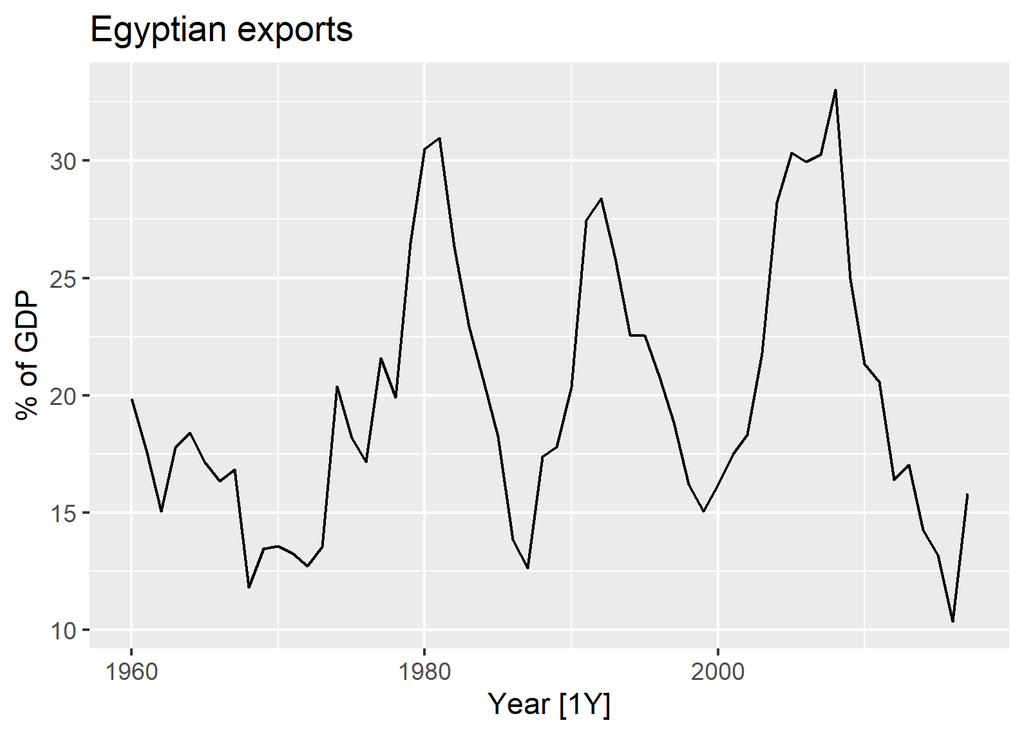

## 자동 ARIMA 추정

```r
fit <- global_economy |>
filter(Code == "EGY") |>
model(ARIMA(Exports))

report(fit)
```

```
## Series: Exports
## Model: ARIMA(2,0,1) w/ mean
##
## Coefficients:
##          ar1      ar2      ma1  constant
##       1.6764  -0.8034  -0.6896    2.5623
## s.e.  0.1111   0.0928   0.1492    0.1161
##
## sigma^2 estimated as 8.046:  log likelihood=-141.57
## AIC=293.13   AICc=294.29   BIC=303.43
```

- 예측 결과는 이집트 경제의 경기순환(cycle) 을 잘 반영하는 것으로 보임

## 예제: 이집트 수출

- 예측 결과

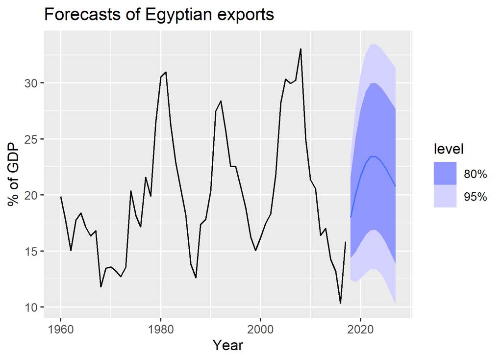

## ARIMA 모형의 이해 (Understanding ARIMA)

## 상수항 \(c\)의 역할

ARIMA 모형에서 상수항 \(c\)는 장기 예측에 중요한 영향을 준다.

| 조건 | 장기 예측 형태 |
| --- | --- |
| \(c = 0,\ d = 0\) | 0에 수렴 |
| \(c = 0,\ d = 1\) | 일정한 값에 수렴 |
| \(c = 0,\ d = 2\) | 직선(linear) 형태 |
| \(c \neq 0,\ d = 0\) | 데이터 평균으로 수렴 |
| \(c \neq 0,\ d = 1\) | 직선 형태 |
| \(c \neq 0,\ d = 2\) | 2차 추세(quadratic trend) (비권장) |

> \(d\)가 커질수록 예측구간(prediction interval)의 폭은 빠르게 증가한다.

## 주기(cycle) 반영 조건

주기적 패턴이 있는 예측(cyclic forecast)을 얻고 싶다면:

- **필수 조건:**  
  \[ p \ge 2 \]
- **추가 조건(AR(2)에서):**  
  \[ \phi_1^2 + 4\phi_2 < 0 \]

이 조건을 만족하면 예측치는 **사인형(sinusoidal)** 순환 패턴을 나타낸다.

## ACF와 PACF

## ACF / PACF의 활용

시계열 그래프만으로는 적절한 \(p, q\) 값을 판단하기 어렵다.  
따라서 다음 함수들이 중요하다:

- **ACF:** \(y_t\)와 \(y_{t-k}\) 간의 상관관계
- **PACF:** 중간 시차의 영향을 제거한 순수 상관관계
- \(k\)차 부분자기상관계수 \(\alpha_k\)는 AR(\(k\)) 모형의 \(\phi_k\) 추정값과 동일

## ACF & PACF 시각화

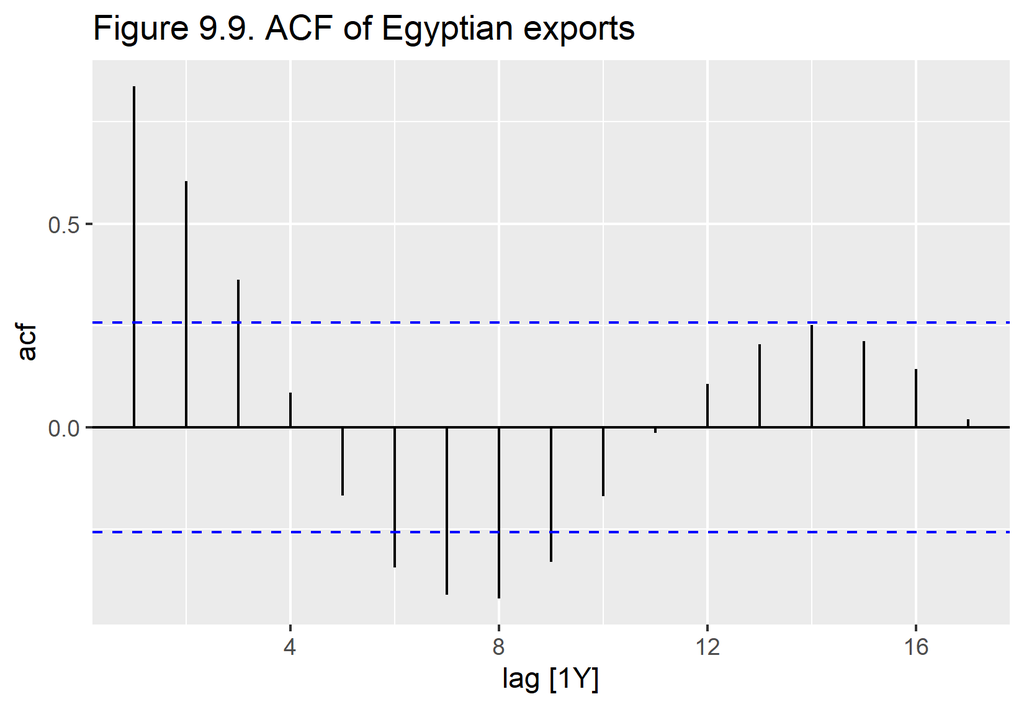

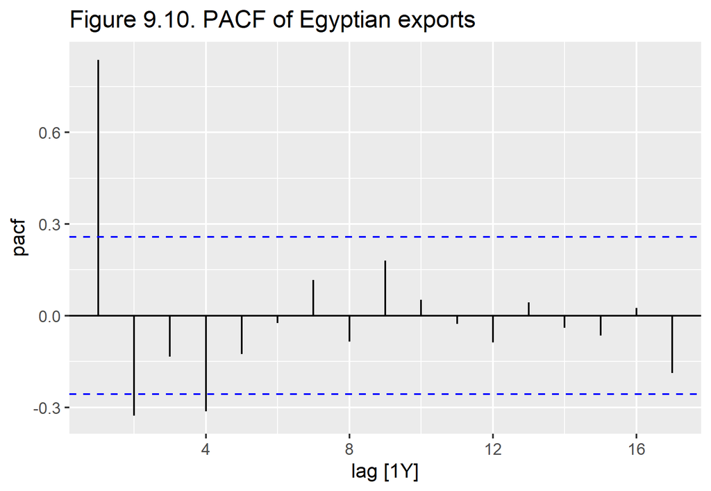

## ACF/PACF를 통한 모형 판별

### ARIMA 모형 판별 규칙

| 모형 | ACF 패턴 | PACF 패턴 |
| --- | --- | --- |
| **ARIMA(\(p, d, 0\))** | 지수적 감쇠 또는 사인형 | lag \(p\)에서 유의, 이후 0 |
| **ARIMA(0, d, q)** | lag \(q\)에서 유의, 이후 0 | 지수적 감쇠 또는 사인형 |

> ✔ ACF/PACF는 AR(자기회귀) 또는 MA(이동평균) 요소를 식별하는 데 유용한 도구이다.

## 예시: ARIMA(4,0,0) 모형 적합

- **ACF:** 감쇠된 사인형 패턴
- **PACF:** lag 4에서 마지막 유의 스파이크

```r
fit2 <- global_economy |>
  filter(Code == "EGY") |>
  model(ARIMA(Exports ~ pdq(4,0,0)))

report(fit2)
```

```
## Series: Exports
## Model: ARIMA(4,0,0) w/ mean
##
## Coefficients:
##          ar1      ar2     ar3      ar4  constant
##       0.9861  -0.1715  0.1807  -0.3283    6.6922
## s.e.  0.1247   0.1865  0.1865   0.1273    0.3562
##
## sigma^2 estimated as 7.885:  log likelihood=-140.53
## AIC=293.05   AICc=294.7   BIC=305.41
```

- 결과: AICc = 294.7
- 자동으로 선택된 ARIMA(2,0,1) 모형(AICc = 294.3)과 거의 동일한 성능

## 모형 탐색 범위 지정

`ARIMA()` 함수는 특정 범위의 \((p, d, q)\) 값을 지정해  
그 안에서 **최적 ARIMA 모형**을 자동 탐색할 수 있다.

### 사용 예시

```r
ARIMA(y ~ pdq(p = 1:3, d = 1, q = 0:2))
```

```
## <ARIMA model definition>
```

이 코드는 다음을 의미한다:

- \(p \in \{1, 2, 3\}\)
- \(d = 1\)
- \(q \in \{0, 1, 2\}\)

→ 이 범위 안에서 가장 적합한 ARIMA 모형을 자동 선택한다.

## ✅ 정리

- **ARIMA(\(p, d, q\))**  
  → AR(자기회귀), 차분(differencing), MA(이동평균)을 결합한 종합 예측모형
- **자동 선택 기능**  
  → `fable::ARIMA()`가 가장 적합한 모형을 자동으로 선택
- **\(p, q\) 선택 기준**  
  → ACF/PACF 패턴을 활용하여 적절한 모형 탐색
- **\(d\) 선택 기준**  
  → 정상성(stationarity)을 확보하기 위한 차분 횟수 결정
- **주기적 예측 가능 조건**  
  → \(p \ge 2\) 이면서 특정 파라미터 조건이 충족되어야 함

## 추정과 차수 선택

## 최대우도추정 (Maximum Likelihood Estimation)

### ARIMA 모형에서의 MLE

ARIMA 모형의 차수 \((p, d, q)\)가 정해지면 추정해야 할 모수는 다음과 같다.

- 상수항 \(c\)
- AR 모수 \(\phi_1, \ldots, \phi_p\)
- MA 모수 \(\theta_1, \ldots, \theta_q\)

`fable` 패키지는 ARIMA 모형을 추정할 때 **최대우도추정(MLE, Maximum Likelihood Estimation)** 을 사용한다.

> MLE는 “관측된 데이터가 나올 확률을 가장 크게 만드는 파라미터”를 찾는 방식이다.

## 최대우도추정 (Maximum Likelihood Estimation)

### MLE와 최소제곱법(LS)의 관계

ARIMA 모형에서 MLE는 다음을 최소화하는 LS 추정과 유사하다.

\[ \sum_{t=1}^{T} \varepsilon_t^2 \]

- **선형 회귀모형의 MLE = 최소제곱법**
- 그러나 ARIMA는 회귀보다 훨씬 복잡
- 서로 다른 소프트웨어는 서로 다른 최적화 알고리즘을 사용 → 결과가 약간 달라질 수 있음

## 로그우도(Log Likelihood)

`fable`은 모형을 추정한 후 **로그우도(log likelihood)** 값을 출력한다.

- 로그우도 = “추정된 모형으로부터 관측된 데이터가 나올 확률의 로그값”
- `ARIMA()`는 주어진 \((p,d,q)\) 안에서 **로그우도를 최대화**하는 파라미터를 찾는다.

## 정보 기준 (Information Criteria)

### AIC (Akaike Information Criterion)

AIC는 모형 선택 기준으로 사용된다.

\[ AIC = -2\log(L) + 2(p + q + k + 1) \]

여기서  
- \(L\): 데이터의 우도(likelihood)  
- \(k = 1\) (상수항 존재), \(k = 0\) (상수항 없음)  
- 마지막 괄호는 모형의 파라미터 수  
(잔차 분산 \(\sigma^2\) 포함)

## 정보 기준 (Information Criteria)

### AICc (Corrected AIC)

표본 크기가 작을 때 사용되는 보정 AIC

\[ AICc = AIC + \frac{2(p+q+k+1)(p+q+k+2)}{T - p - q - k - 2} \]

> `fable`은 기본적으로 AICc를 사용  
> AICc는 시계열 모형 선택에서 매우 안정적

## 정보 기준 (Information Criteria)

### BIC (Bayesian Information Criterion)

\[ BIC = AIC + [\log(T) - 2](p + q + k + 1) \]

AIC, AICc, BIC 모두 **작을수록 좋은 모형**을 의미한다.

## 차분 차수 \(d\) 선택 시 주의점

### 왜 AIC로 \(d\)를 선택하면 안 되는가?

AIC, AICc, BIC는 **서로 다른 차분 차수(d)** 를 가진 모형을 비교하는 데 적합하지 않다.

- 이유: 차분을 하면 데이터가 달라지므로 **우도 함수가 다른 데이터**를 기준으로 계산됨  
  → 즉, \(d\)가 다르면 AIC 값이 **비교 불가능**

> 따라서,  
> - \(d\)는 **정상성 판단(KPSS, ACF 패턴 등)** 으로 먼저 결정  
> - 이후 AICc로 \((p, q)\)를 선택하는 것이 바람직

## ✅ 정리

- ARIMA 모형은 **최대우도추정(MLE)** 을 사용해 파라미터를 추정
- 정보 기준(AIC, AICc, BIC)은 **모형 선택**에 유용
- 그러나 AIC류는 차분 차수 \(d\) 판단에는 부적절 → 정상성 진단 사용
- AICc는 특히 시계열 모형 선택에 선호됨
- 모형 선택 절차:
1. 정상성 확인 → \(d\) 결정
2. AICc 최소화 → \(p, q\) 결정
3. 필요 시 주기성(cycle)·계절성까지 확장

## ARIMA() 함수를 이용하여 모형 추정하기

## Hyndman–Khandakar 알고리즘 개요

`fable` 패키지의 `ARIMA()` 함수는  
**Hyndman & Khandakar (2008)** 알고리즘을 변형하여 사용한다.

이 알고리즘은 다음 세 가지를 결합한 자동 ARIMA 모형 선택 절차이다.

- 단위근 검정(Unit root tests)
- AICc 최소화
- 최대우도추정(MLE)

`ARIMA()`의 옵션으로 다양한 변형이 가능하나,  
여기서는 **기본(default)** 알고리즘만 다룬다.

## Hyndman–Khandakar 알고리즘

### 1️⃣ 차분 횟수 \(d\) 결정

(\(0 \le d \le 2\))

- 반복적인 **KPSS 단위근 검정**을 사용하여  
  필요한 차분 횟수 \(d\)를 결정한다.

### 2️⃣ \(p\)와 \(q\) 선택

(AICc 최소화 기반)

- 데이터에 대해 \(d\)회 차분을 적용한 뒤,  
  **AICc가 최소가 되도록** AR 차수 \(p\)와 MA 차수 \(q\)를 선택한다.
- 모든 조합을 탐색하는 대신,  
  **단계적 탐색(stepwise search)** 으로 모형 공간을 효율적으로 이동한다.

## Hyndman–Khandakar 알고리즘

### 3️⃣ 초기 모형 네 가지 적합

다음 네 가지 모형이 먼저 적합된다.

- ARIMA\((0, d, 0)\)
- ARIMA\((2, d, 2)\)
- ARIMA\((1, d, 0)\)
- ARIMA\((0, d, 1)\)

> 💡 **상수항 \(c\)**  
> - \(d = 2\)일 때만 상수항 제외  
> - \(d \le 1\)이면 다음 모형도 추가로 적합됨:  
> - ARIMA\((0, d, 0)\) **without constant**

## Hyndman–Khandakar 알고리즘

### 4️⃣ “현재 모형(Current model)” 설정

- 위 단계에서 얻은 모형 중  
  **AICc가 가장 작은 모형을 현재 모형으로 설정**한다.

### 5️⃣ 현재 모형에 대한 변형 모델 탐색

현재 모형에서 다음 변화를 주어 모형을 새로 적합해 본다.

- \(p\)와/또는 \(q\) 값을 **±1** 만큼 변화
- **상수항 포함/제외** 여부 변경

현재까지 평가한 모형 중 가장 AICc가 작은 모형이  
새로운 “현재 모형”이 된다.

## Hyndman–Khandakar 알고리즘

### 6️⃣ 최적 모형 선택

- 위의 탐색을 반복
- **더 낮은 AICc를 주는 모형이 없을 때** 알고리즘 종료
- 해당 모형이 최종 ARIMA 모형이 된다.

## ✅ 정리

- `ARIMA()`는 **KPSS → 차분 → 단계적 탐색 → MLE → AICc 최소화**의 절차로 작동
- 모형 선택을 자동화해 주지만,  
  **기저 메커니즘을 이해하고 있어야 해석과 응용에 강해짐**
- 수동으로 \(p,d,q\)를 선택하려고 할 때도 이 알고리즘 로직을 참고하면 도움이 된다.

## Hyndman–Khandakar 알고리즘의 탐색

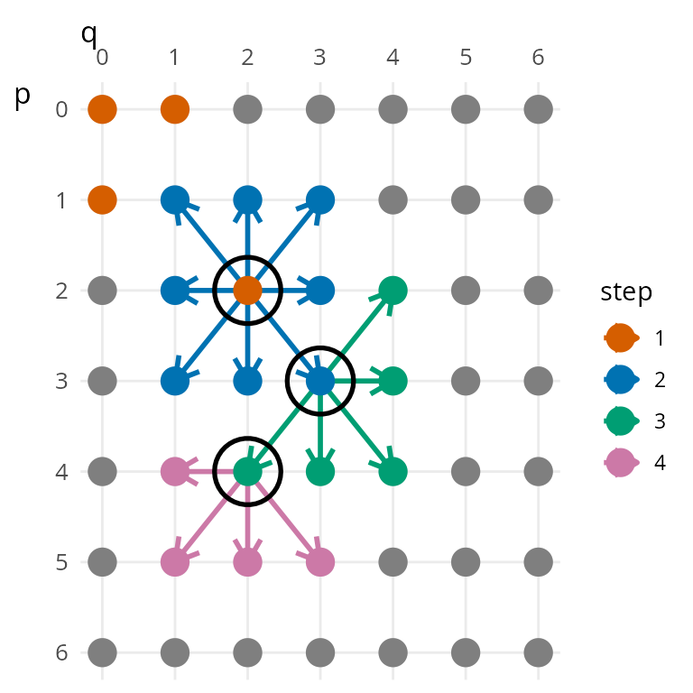

## 알고리즘의 탐색 공간(ARMA 차수 공간)

앞 그림은 Hyndman–Khandakar 알고리즘이 ARMA 모형의 차수 공간(ARMA(\(p,q\)))을 어떻게 탐색하는지 도식적으로 보여준다.

- 격자(grid)의 **세로축(vertical)**: AR 차수 \(p\)
- 격자의 **가로축(horizontal)**: MA 차수 \(q\)
- 좌측 상단: **ARMA(0,0)** 부터 시작

## 초기 탐색 모델들

- 주황색(orange) 셀: 알고리즘이 처음 고려하는 네 가지 초기 모형
- 이 예시에서는 ARMA(2,2) 모형이 이 네 개 중 **가장 작은 AICc**를 가짐
- 이 모형이 **현재 모형(current model)** 이 되며 그림에서는 **검은색 원(black circle)** 으로 표시됨

## 탐색 절차: 인접 모형(neighbouring models) 탐색

### 단계적(stepwise) 이동

- 알고리즘은 현재 모형을 기준으로 **인접한 ARMA 차수 조합**을 탐색
- 그림의 **파란 화살표(blue arrows)** 가 탐색 방향을 나타냄
- 더 낮은 AICc를 주는 모형을 찾으면, 해당 모형이 **새로운 현재 모형(new current model)** 이 된다

### 예시 결과

- 초기 현재 모형: **ARMA(2,2)**
- 탐색 완료 후 변경된 현재 모형: **ARMA(3,3)**
- 탐색을 계속한 결과, 최종적으로 선택된 모형은  
  **ARMA(4,2)**

## Hyndman–Khandakar 알고리즘 옵션

### 1) greedy = TRUE (기본값)

- 기본 설정에서는 **더 나은 모형을 발견하는 즉시(current model을 즉시 교체)**
- 즉, 모든 이웃 모형을 다 탐색하지 않음

### 2) greedy = FALSE

- 모든 인접 모형(neighbours)에 대한 **완전 탐색(full neighbourhood search)** 수행

## 탐색 속도 향상 옵션

### approximation = TRUE (기본값)

- 일부 계산을 근사(approximation)하여 탐색 속도 증가
- 그러나 근사 때문에 **최소 AICc 모형을 놓칠 위험**도 존재

### approximation = FALSE

- 근사 없이 **정확한 계산**을 수행
- 속도는 느려질 수 있음

## 탐색 속도 향상 옵션

### stepwise = TRUE (기본값)

- 단계적(stepwise) 탐색: 제한된 모형 집합만 탐색하여 빠른 속도를 보장

### stepwise = FALSE

- 훨씬 더 많은 모형을 탐색
- 더 정확한 모형 선택 가능하지만 **연산량 증가**

## 정리

- Hyndman–Khandakar 알고리즘은  
  **초기 모형 → 인접 모형 탐색 → 더 나은 모형을 찾으면 교체**  
  과정으로 ARIMA 모형을 자동 선택함
- greedy, stepwise, approximation 옵션을 통해  
  **탐색 범위와 정확도 vs 속도 조절 가능**

## 비계절 ARIMA 모형 적합 절차

### 1️⃣ 데이터 플로팅 및 이상치 확인

- 시계열을 먼저 **그래프로 확인**한다.
- 추세, 계절성, 구조적 변화, **이상치(outliers)** 를 파악한다.

### 2️⃣ 필요 시 변환(Transformation)

- 분산 안정화가 필요하면  
  **Box-Cox 변환(로그 변환 포함)** 을 고려한다.

### 3️⃣ 정상성 확보를 위한 차분

- 데이터가 **비정상(non-stationary)** 이라면  
  **1차 차분(first differencing)** 을 수행
- 필요한 경우 한 번 더 차분 → **정상성 확보될 때까지 반복**

## 비계절 ARIMA 모형 적합 절차

### 4️⃣ ACF/PACF 분석

### 모델 형태 판단

- **ACF/PACF** 플롯을 보고 다음 중 하나가 적합한지 판단:
  - ARIMA(\(p,d,0\))
  - ARIMA(0,\(d,q\))

> ✔ ACF/PACF는 AR/MA 차수를 판별하는 가장 대표적인 도구

### 5️⃣ 후보 모형 적합 및 AICc 비교

- 선택한 \((p,d,q)\) 값으로 모형을 적합
- **AICc(Akaike’s Information Criterion corrected)** 를 이용해  
  더 나은 모형이 있는지 추가 탐색

## 비계절 ARIMA 모형 적합 절차

### 6️⃣ 잔차 진단 (Residual Diagnostics)

- 적합된 모형의 **잔차(residuals)** 를 다음을 통해 점검:
  - 잔차의 ACF 플롯
  - 포트먼토 검정(portmanteau test, 예: Ljung–Box)
- 잔차가 **백색잡음(white noise)** 처럼 보이지 않으면  
  → **모형을 수정**하고 다시 시도

### 7️⃣ 예측(Forecasting)

- 잔차가 백색잡음처럼 보이면, 모형이 잘 적합(fitting)된 것으로 판단하고 **예측치를 계산**

## ✔ Hyndman–Khandakar 알고리즘이 하는 일

Hyndman–Khandakar 자동 ARIMA 알고리즘은 위 절차 중 다음 단계만 수행한다:

- **3단계:** 차분(d) 선택
- **4단계:** ACF/PACF 기반 탐색
- **5단계:** AICc 최소화 기반 모형 선택

> 나머지 단계(플로팅, 변환, 잔차 진단 등)는**사용자가 직접 수행해야 함**

## Hyndman–Khandakar 알고리즘 순서도

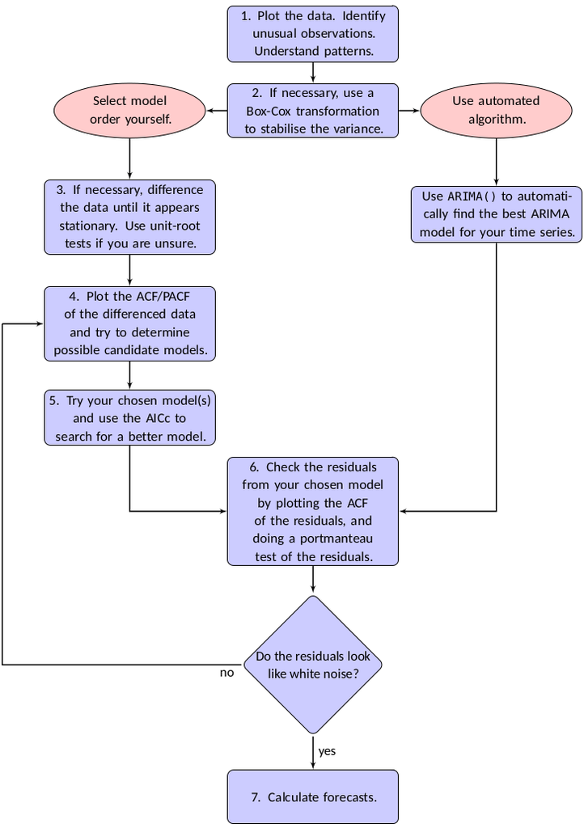

## Portmanteau 잔차 검정 (ARIMA 모형)

### 1️⃣ ARIMA 모형에서의 포트먼토(portmanteau) 검정

ARIMA 모형의 잔차에 대해 포트먼토 검정을 수행할 때는 단순히 \(\ell\)개의 시차를 사용한 검정 통계량을 적용하는 것보다 **모형의 파라미터 수를 고려해 자유도(d.f.)를 조정**하는 것이 더 정확하다.

## Portmanteau 잔차 검정 (ARIMA 모형)

### 2️⃣ 자유도 조정

검정에 사용되는 자유도는 다음과 같이 설정한다.

\[ \text{d.f.} = \ell - K \]

여기서  
- \(\ell\): 검정에 사용한 시차(lag)의 수  
- \(K\): ARIMA 모형의 AR 및 MA 파라미터 수  
- 비계절 ARIMA(\(p,d,q\))의 경우  
\[ K = p + q \]

즉, ARIMA 모형을 적합할 때는  
잔차 검정에서도 **모형 복잡도(complexity)를 반영**해야 한다.

## Portmanteau 잔차 검정 (ARIMA 모형)

### 3️⃣ fable에서의 적용

`fable`의 `ljung_box()` 함수는 `dof`(degrees of freedom) 인자를 통해 자유도 조정을 적용할 수 있다.

## 예제: 중아프리카 공화국 수출

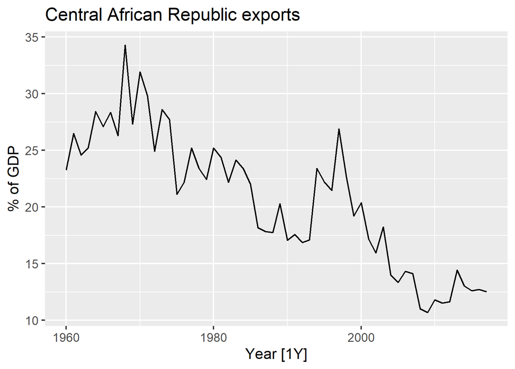

## 시계열 탐색: 정상성 여부 확인

### 1️⃣ 비정상성(non-stationarity)의 존재

시계열 그래프(time plot)를 보면 전체적으로 하락하는 경향이 있어 **비정상성(non-stationarity)** 이 관찰된다.

- **1994년의 개선(improvement)** 은 군사정권을 전복한 새로운 정부 출범 이후 단기적으로 경제가 회복된 영향
- 하지만 곧 이어진 사회적 불안정으로 경제는 다시 하락세로 전환됨

## 시계열 탐색: 정상성 여부 확인

### 2️⃣ 분산 변화 없음 → Box-Cox 변환 불필요

시계열 전체에 걸쳐 **분산의 변화(evidence of changing variance)** 는 보이지 않는다.  
따라서  
> **Box-Cox 변환(로그 변환 등)은 적용하지 않는다.**

### 3️⃣ 비정상성 해결: 차분(Differencing)

### 1차 차분(First difference)

비정상성을 해결하기 위한 방법으로 데이터에 **1차 차분(first differencing)** 을 적용한다.

이렇게 변환한 시계열이 다음 그림에 제시되어 있다.

## 시계열 탐색: 정상성 여부 확인

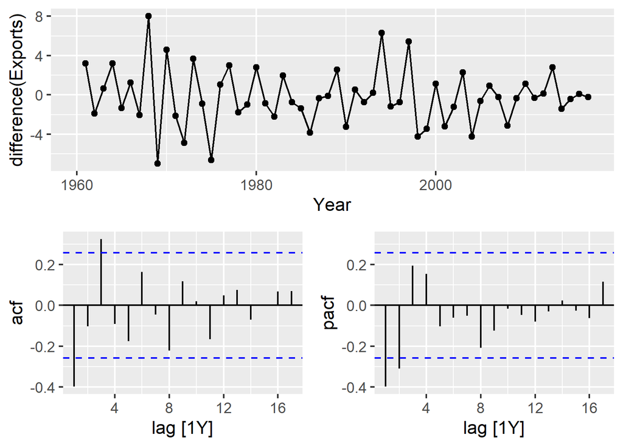

## PACF/ACF 기반 초기 ARIMA 후보 모형 선택

### 1️⃣ PACF 기반 후보

앞의 그림의 **PACF**를 보면 **AR(2)** 모형이 적합해 보인다.

→ 초기 후보 모형: **ARIMA(2,1,0)**

### 2️⃣ ACF 기반 후보

반면 **ACF**는 **MA(3)** 모형이 적합한 듯한 패턴을 보인다.

→ 대안 후보 모형: **ARIMA(0,1,3)**

## 후보 모형 및 자동 모형 비교

### 3️⃣ 네 가지 모형 적합

다음 네 가지 모형을 비교하였다.

1. 수동 지정: ARIMA(2,1,0)
2. 수동 지정: ARIMA(0,1,3)
3. 자동 선택: stepwise = TRUE (기본)
4. 자동 선택: stepwise = FALSE (보다 광범위한 탐색)

## 후보 모형 및 자동 모형 비교

### 4️⃣ AICc 비교 결과

- 네 모형 모두 **AICc 값이 거의 동일**
- 전체 탐색(stepwise=FALSE) 결과  
  → 최적 모형: **ARIMA(3,1,0)**
- 그 다음으로 좋은 모형:  
  → ARIMA(2,1,0), ARIMA(0,1,3)
- 자동 stepwise 방식(stepwise=TRUE)은  
  → **ARIMA(2,1,2)** 선택  
  → 네 모형 중 **AICc 가장 높음**(→ 상대적으로 덜 적합)

## 잔차 진단 (Residual Diagnostics)

### 5️⃣ ARIMA(3,1,0) 잔차의 ACF

- ARIMA(3,1,0)의 잔차 ACF에서 **모든 자기상관이 임계값 안에 있음**
- → 잔차가 **백색잡음(white noise)** 처럼 보임

## 잔차 진단 (Residual Diagnostics)

```r
caf_fit <- global_economy |>
  filter(Code == "CAF") |>
  model(arima210 = ARIMA(Exports ~ pdq(2,1,0)),
        arima013 = ARIMA(Exports ~ pdq(0,1,3)),
        stepwise = ARIMA(Exports),
        search = ARIMA(Exports, stepwise=FALSE))

caf_fit |> pivot_longer(!Country, names_to = "Model name",
                         values_to = "Orders")
```

```
## # A mable: 4 x 3
## # Key:     Country, Model name [4]
##   Country                  `Model name`         Orders
##   <fct>                    <chr>               <model>
## 1 Central African Republic arima210     <ARIMA(2,1,0)>
## 2 Central African Republic arima013     <ARIMA(0,1,3)>
## 3 Central African Republic stepwise     <ARIMA(2,1,2)>
## 4 Central African Republic search       <ARIMA(3,1,0)>
```

```r
glance(caf_fit) |> arrange(AICc) |> select(.model:BIC)
```

```
## # A tibble: 4 × 6
##   .model   sigma2 log_lik   AIC  AICc   BIC
##   <chr>     <dbl>   <dbl> <dbl> <dbl> <dbl>
## 1 search     6.52   -133.  274.  275.  282.
## 2 arima210   6.71   -134.  275.  275.  281.
## 3 arima013   6.54   -133.  274.  275.  282.
## 4 stepwise   6.42   -132.  274.  275.  284.
```

## 잔차 진단 (Residual Diagnostics)

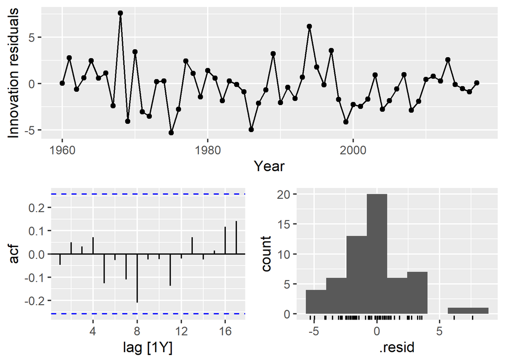

## 잔차 진단 (Residual Diagnostics)

### 6️⃣ 포트먼토 검정

- 포트먼토 검정에서  
  \(K=3\) (AR 파라미터 수 = 3)으로 설정
- 큰 p-값이 나옴  
  → 잔차가 **백색잡음**이라는 추가적인 증거

```r
augment(caf_fit) |>
  filter(.model=='search') |>
  features(.innov, ljung_box, lag = 10, dof = 3)
```

```
## # A tibble: 1 × 4
##   Country                  .model lb_stat lb_pvalue
##   <fct>                    <chr>    <dbl>     <dbl>
## 1 Central African Republic search    5.75     0.569
```

## 7️⃣ 최종 모형의 예측 (Forecasts)

예측 결과는 다음 장 그림에 제시됨.

- 평균 예측(mean forecasts)은 **랜덤워크(ARIMA(0,1,0)) 예측과 매우 유사**
- 하지만 AR·MA 항을 포함한 모형은 **예측구간(prediction intervals)** 이 랜덤워크보다 **훨씬 좁음**

> ✔ 즉, ARIMA(3,1,0)은 평균 수준의 예측은 랜덤워크와 비슷하지만, **불확실성(variance)을 훨씬 잘 줄여 주는** 모형임.

## 7️⃣ 최종 모형의 예측 (Forecasts)

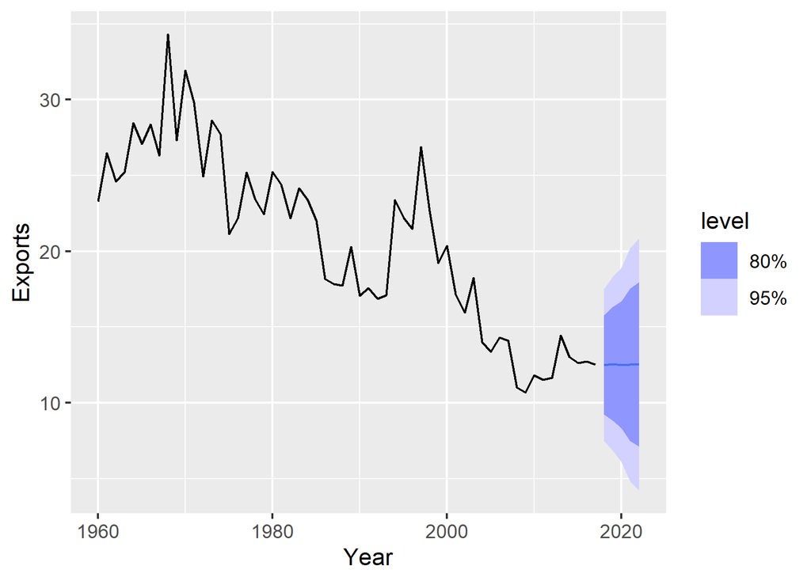

## ARIMA 모형에서의 상수항 이해하기

## 1️⃣ 비계절 ARIMA 모형의 일반식

비계절 ARIMA 모형은 다음과 같이 표현할 수 있다.

\[ (1 - \phi_1 B - \cdots - \phi_p B^p)(1-B)^d y_t = c + (1 + \theta_1 B + \cdots + \theta_q B^q)\,\varepsilon_t \tag{9.3} \]

또는 다음과 동치이다.

\[ (1 - \phi_1 B - \cdots - \phi_p B^p)(1-B)^d \left( y_t - \frac{\mu t^d}{d!} \right) = (1 + \theta_1 B + \cdots + \theta_q B^q)\,\varepsilon_t \tag{9.4} \]

여기서

- \[ c = \mu(1 - \phi_1 - \cdots - \phi_p) \]
- \(\mu\): \((1-B)^d y_t\)의 평균(mean)

## 2️⃣ fable과 R의 다른 패키지의 차이

- **fable 패키지**: 식 (9.3)의 파라미터화(parameterisation)를 사용
- **다른 R 구현들**: 보통 식 (9.4)를 사용

즉, 같은 ARIMA 모형이라도 R 패키지마다 **상수항의 의미가 다르게 보일 수 있음**.

## 3️⃣ 상수항의 의미 (Interpretation of the constant)

### 상수항이 포함될 때의 효과

ARIMA 모형에서 상수항을 포함하면 예측값(forecasts)에 **차수 \(d\)** 의 다항식 추세(polynomial trend)가 추가된다.

- 상수 포함 → **\(d\)차 다항식 추세**
- 상수 미포함 → **\(d-1\)차 다항식 추세**

특별한 경우:

- \(d = 0\)일 때  
  → \(\mu\)는 단순히 \(y_t\)의 **평균(mean)**

## 4️⃣ ARIMA()의 상수항 자동 선택 규칙

### 기본 동작 (default behaviour)

- **\(d = 0\)** 또는 **\(d = 1\)**  
  → 상수를 포함하면 **AICc가 개선되는 경우에만** 상수 포함
- **\(d > 1\)**  
  → 상수항 **항상 제외**  
  (고차 다항식 추세는 예측 시 매우 위험하기 때문)

### 강제로 상수 포함/제외하기

수식 안에서 0 또는 1을 사용하여 상수항을 제어할 수 있다.

## 예측 (forecastng)

## ARIMA 점예측 (Point forecasts)

### 1️⃣ 점예측은 어떻게 계산되는가?

ARIMA 모형에서 점예측(point forecasts)은 다음 **3단계 절차**로 계산된다.

### Step 1: ARIMA 방정식을 전개

- \(y_t\)를 **좌변(left-hand side)** 에 두고  
  나머지 항은 **우변(right-hand side)** 으로 옮긴다.

### Step 2: 미래 시점으로 치환

- 식의 \(t\)를 **미래 시점**인 \(T+h\)로 치환한다.

## ARIMA 점예측 (Point forecasts)

### 1️⃣ 점예측은 어떻게 계산되는가?

### Step 3: 미래 관측치·오차의 대체

- 미래 관측치: **해당 시점의 예측값**으로 대체
- 미래 오차 \(\varepsilon_{T+h}\): **0**으로 대체
- 과거 오차 \(\varepsilon_{T-k}\): **잔차(residual)** 로 대체

## ARIMA 점예측 (Point forecasts)

### 4️⃣ Recursive Forecasting

- \(h = 1\)부터 시작하여  
  \(h = 2, 3, \dots\)로 확장
- 이전 시점의 예측값을 사용하여  
  **순차적으로(iteratively)** 미래 예측값 계산

## 예시: ARIMA(3,1,1) 모형

### ARIMA(3,1,1)의 Backshift 표현

\[ (1 - \hat\phi_1 B - \hat\phi_2 B^2 - \hat\phi_3 B^3)(1-B)y_t = (1 + \hat\theta_1 B)\,\varepsilon_t \]

### Step 1: 좌변 전개

\[ \begin{aligned} [1 &- (1+\hat\phi_1)B + (\hat\phi_1 - \hat\phi_2)B^2 \\ &+ (\hat\phi_2 - \hat\phi_3)B^3 + \hat\phi_3 B^4] y_t = (1 + \hat\theta_1 B)\varepsilon_t \end{aligned} \]

### Backshift 적용

\[ \begin{aligned} y_t &- (1+\hat\phi_1)y_{t-1} + (\hat\phi_1-\hat\phi_2)y_{t-2} \\ &+ (\hat\phi_2-\hat\phi_3)y_{t-3} + \hat\phi_3 y_{t-4} \\ &= \varepsilon_t + \hat\theta_1 \varepsilon_{t-1} \end{aligned} \]

## 예시: ARIMA(3,1,1) 모형

### ARIMA(3,1,1)의 Backshift 표현

### 모든 항을 우변으로 이동

\[ \begin{aligned} y_t =&\ (1+\hat\phi_1)y_{t-1} - (\hat\phi_1-\hat\phi_2)y_{t-2} \\ &- (\hat\phi_2 - \hat\phi_3)y_{t-3} - \hat\phi_3 y_{t-4} \\ &+ \varepsilon_t + \hat\theta_1 \varepsilon_{t-1} \tag{9.5} \end{aligned} \]

> 형태는 ARIMA(4,0,1)처럼 보이나, **ARIMA(3,1,1)의 구조를 전개한 것**으로 stationarity 조건을 만족하지 않으므로 ARIMA(4,0,1)로 볼 수 없음.

## Step 2: 1-step ahead 예측

### \(t = T+1\)로 치환

\[ \begin{aligned} y_{T+1} =&\ (1+\hat\phi_1)y_T - (\hat\phi_1 - \hat\phi_2)y_{T-1} \\ &- (\hat\phi_2 - \hat\phi_3)y_{T-2} - \hat\phi_3 y_{T-3} \\ &+ \varepsilon_{T+1} + \hat\theta_1 \varepsilon_T \end{aligned} \]

### 미래 오차 치환

- \(\varepsilon_{T+1} = 0\)
- \(\varepsilon_T = e_T\) (잔차)

## Step 2: 1-step ahead 예측

따라서,

\[ \begin{aligned} \hat y_{T+1|T} =&\ (1+\hat\phi_1)y_T - (\hat\phi_1 - \hat\phi_2)y_{T-1} \\ &- (\hat\phi_2 - \hat\phi_3)y_{T-2} - \hat\phi_3 y_{T-3} \\ &+ \hat\theta_1 e_T \end{aligned} \]

\[ \hat y_{T+2|T} = (1+\hat\phi_1)\hat y_{T+1|T} - (\hat\phi_1 - \hat\phi_2) y_{T} - (\hat\phi_2-\hat\phi_3)y_{T-1} - \hat\phi_3 y_{T-2} \]

- \(\varepsilon_{T+2},\ \varepsilon_{T+1} = 0\)
- \(y_{T+1}\) 대신 \(\hat y_{T+1|T}\) 사용

## 🎯 결론: Recursive Forecasting

- ARIMA 모형의 점예측은 **전개된 ARIMA 구조를 h-step ahead로 치환**한 뒤 **미래 오차를 0**, **미래 관측값을 예측값으로 대체**하여 순차적으로 계산된다.
- 이러한 방식으로 **원하는 만큼의 미래 예측값**을 생성할 수 있다.

## ARIMA 예측구간 (Prediction Intervals)

### 1️⃣ 예측구간 계산의 기본 개념

ARIMA 모형에서 **예측구간(prediction interval)** 계산은  
ARIMA 구조가 복잡하기 때문에 비교적 난해하다.  
여기서는 기본적인 사례만 다룬다.

## 2️⃣ 1-step(1단계) 예측구간

1단계 예측구간은 비교적 간단하다.

- \(\hat\sigma\): 잔차(residuals)의 표준편차라면
- 95% 예측구간은 다음과 같다:

\[ \hat{y}_{T+1|T} \pm 1.96\,\hat{\sigma} \]

이 식은 **모든 ARIMA 모형**에서 성립한다  
(모수나 차수와 무관).

## ARIMA 예측구간 (Prediction Intervals)

### 3️⃣ ARIMA(0,0,q) = MA(q) 모형의 예측구간

MA(q) 모형:

\[ y_t = \varepsilon_t + \sum_{i=1}^q \theta_i \varepsilon_{t-i} \]

h-step ahead 예측분산:

\[ \hat{\sigma}^2_h = \hat{\sigma}^2 \left[ 1 + \sum_{i=1}^{h-1} \hat{\theta}_i^2 \right], \qquad h = 2,3,\dots \]

여기서  
\[ \hat{\theta}_i = 0 \quad (i > q) \]

95% 예측구간:

\[ \hat{y}_{T+h|T} \pm 1.96\,\hat{\sigma}_h \]

## ARIMA 예측구간 (Prediction Intervals)

### 4️⃣ AR(1) 모형도 MA(∞)로 표현 가능

AR(1) 모형은 MA(∞) 모형으로 표현할 수 있다.

→ 따라서 MA(q) 예측구간 계산법을 AR(1)에도 동일하게 적용할 수 있다.

### 5️⃣ 그 외 ARIMA(p,d,q)의 예측구간

일반적인 ARIMA(\(p,d,q\)) 모형의 h-step 예측분산/예측구간 공식은 복잡하며, 자세한 내용은 “Brockwell & Davis (2016)”과 같은 고급 교재에 제시되어 있다.

## ARIMA 예측구간 (Prediction Intervals)

### 6️⃣ 예측구간의 전제 조건

ARIMA 예측구간의 정확성은 다음 두 가지 전제에 의존한다.

- 잔차가 **비상관(uncorrelated)**
- 잔차가 **정규분포(normal)**

이 중 하나라도 위배되면 예측구간은 부정확해질 수 있다.

→ **따라서 예측 전에 항상 다음을 확인해야 함:**

- 잔차 ACF
- 잔차 히스토그램

## ARIMA 예측구간 (Prediction Intervals)

### 7️⃣ 비정규 분포 잔차의 경우: Bootstrap 예측구간

잔차가 **비상관이지만 정규분포가 아닐 때**  
→ bootstrap 예측구간을 사용할 수 있다.

### 8️⃣ 예측구간의 증가 패턴

- 일반적으로 ARIMA 예측구간은 **시간이 멀어질수록 넓어진다**  
  (horizon ↑ → prediction interval width ↑)

## ARIMA 예측구간 (Prediction Intervals)

### ▣ Stationary 모형 (\(d = 0\))

- 장기적으로 **예측구간의 폭이 수렴(converge)**
- 충분히 먼 미래에서는 모든 예측구간이 거의 동일해짐

### ▣ 비정상 모형 (\(d \ge 1\))

- 미래로 갈수록 **예측구간이 무한히 증가**

## ARIMA 예측구간 (Prediction Intervals)

### 9️⃣ ARIMA 예측구간은 대체로 “좁다”

예측구간이 실제보다 좁아지는 이유:

- 잔차(residual)의 변동만 반영
- **모수 추정의 불확실성(parameter uncertainty)** 미반영
- **모형 선택의 불확실성(model selection uncertainty)** 미반영
- 과거 패턴이 미래에도 유지된다는 강한 가정 포함

→ 결과적으로 **실제 불확실성을 과소추정(underestimate)** 하는 경향이 있음

## 요약

- **1-step 예측구간 공식은 간단하며 모든 ARIMA에 공통**
- **MA(q)** 모형: 예측분산을 명시적으로 계산 가능
- **AR(1)**: MA(∞) 표현을 이용해 예측구간 계산 가능
- **일반 ARIMA(\(p,d,q\))**: 예측구간 계산은 복잡  
  → 정규성·독립성 가정 필요
- **bootstrap 예측구간**: 잔차가 비정규일 때 유용
- \(d=0\): 예측구간 수렴
- \(d \ge 1\): 예측구간 무한 증가
- ARIMA 예측구간은 종종 **실제보다 좁게 나타나는 특성**이 있음